# Pruning & Rooting Phylogenetic Trees with ggTree

Hilal Samut

2025-03-31

# Goals

1. Load the [FastTree2](https://journals.plos.org/plosone/article?id=10.1371/journal.pone.0009490) unrooted tree that we calculated in `analysis/04A_Phylogenetic_Tree_Construction.Rmd` and `raw_preprocessed_physeq``.
2. Merge the unrooted tree to the `raw_preprocessed_phyloseq` object.
3. Visualize and inspect tree with [ggtree](https://besjournals.onlinelibrary.wiley.com/doi/full/10.1111/2041-210X.12628).
4. Evaluate long branches & prune ASVs, if needed. *If your dataset has long branches, you will need to do this before rooting!!*
5. After pruning, root the tree, ideally within the Archaea and, if not, mid-root the tree.
6. Combine the new, rooted tree with the phyloseq object.
7. Save 2 phyloseq objects: 1. Unrooted tree phyloseq object, 2. Rooted tree phyloseq object.
1. Our previously pre-processed phyloseq object that has chloroplasts, mitochondria, reverse complements, and negative controls removed, which is located in `data/03_PreProcessing/raw_preprocessed_physeq`.
2. The raw, unrooted maximum likelihood tree that we generated using [FastTree2](https://journals.plos.org/plosone/article?id=10.1371/journal.pone.0009490), which is located in `data/04_PhylogeneticTree/ASVs_unrooted.tree`

## Outputs

1. The output of this file will be a S4 phloseq objected called `phytree_preprocessed_physeq`, which we will save to `data/04_PhylogeneticTree/`.

# Before you start

## Timing of this script

Let’s record how long this file took to run on the class server, which we will record at the end of the script.

```r
# What time did we start running this script?
start_time <- Sys.time()
```

## Set my seed

```r
# Any number can be chosen
set.seed(238428)
```

## Load Packages

```r
#install.packages("phylobase")
pacman::p_load(tidyverse, phyloseq, ggtree, phytools, tidytree, phylobase,
               install = FALSE)
```

## 1. Load Data files

```r
# Preprocessed phyloseq object
load("data/03_PreProcessing/raw_preprocessed_physeq.RData")

# Inspect the phyloseq object
raw_preprocessed_physeq
```

```
## phyloseq-class experiment-level object
## otu_table()   OTU Table:         [ 455 taxa and 108 samples ]
## sample_data() Sample Data:       [ 108 samples by 52 sample variables ]
## tax_table()   Taxonomy Table:    [ 455 taxa by 9 taxonomic ranks ]
```

```r
# Load in the tree!
unrooted_tree <- read.tree("data/04_PhylogeneticTree/ASVs_unrooted.tree")

# Take a look at the tree
unrooted_tree
```

```
##
## Phylogenetic tree with 455 tips and 453 internal nodes.
##
## Tip labels:
##   ASV_0073, ASV_0341, ASV_0519, ASV_0521, ASV_0425, ASV_0490, ...
## Node labels:
##   , 0.000, 0.000, 0.939, 0.859, 0.000, ...
##
## Unrooted; includes branch length(s).
```

```r
str(unrooted_tree)
```

```
## List of 5
##  $ edge       : int [1:907, 1:2] 456 456 456 457 458 459 460 460 459 461 ...
##  $ edge.length: num [1:907] 0.00257 0.00257 0.00055 0.00055 0.00055 0.00257 0.00055 0.00257 0.00055 0.00257 ...
##  $ Nnode      : int 453
##  $ node.label : chr [1:453] "" "0.000" "0.000" "0.939" ...
##  $ tip.label  : chr [1:455] "ASV_0073" "ASV_0341" "ASV_0519" "ASV_0521" ...
##  - attr(*, "class")= chr "phylo"
##  - attr(*, "order")= chr "cladewise"
```

# 2. Merge Unrooted Tree & `raw_preprocessed_physeq`

Now that we’ve loaded in both our `raw_preprocessed_physeq` and the unrooted tree, let’s merge them into one phyloseq object that can be used to plot the tree with ggtree.

```r
# Intuition check
stopifnot(ntaxa(raw_preprocessed_physeq) == ntaxa(unrooted_tree))
# No news is good news!

# Merge the tree with the phyloseq object
unrooted_physeq <-
  merge_phyloseq(raw_preprocessed_physeq, unrooted_tree)

# Let's take a look!
unrooted_physeq
```

```
## phyloseq-class experiment-level object
## otu_table()   OTU Table:         [ 455 taxa and 108 samples ]
## sample_data() Sample Data:       [ 108 samples by 52 sample variables ]
## tax_table()   Taxonomy Table:    [ 455 taxa by 9 taxonomic ranks ]
## phy_tree()    Phylogenetic Tree: [ 455 tips and 453 internal nodes ]
```

# 3. Visualize and inspect tree with [ggtree](https://besjournals.onlinelibrary.wiley.com/doi/full/10.1111/2041-210X.12628).

Now, let’s take a look

## Kingdom Level Tree

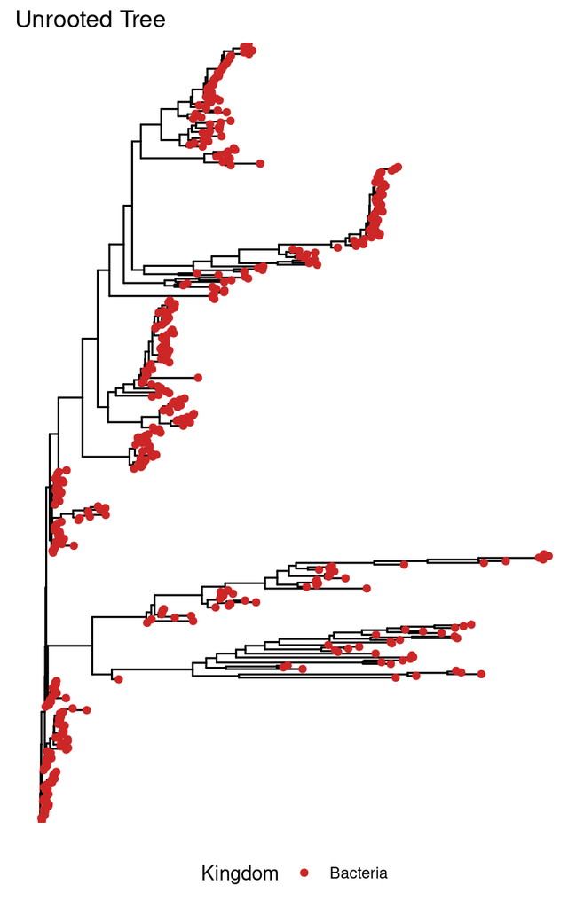

```r
# Make a basic tree with the domains
kingdom_tree <-
  ggtree(unrooted_physeq) +
  # color tips by kingdom
  geom_tippoint(mapping = aes(color = Kingdom)) +
  # add a title
  labs(title = "Unrooted Tree") +
  scale_color_manual(values = c("firebrick3", "cornflowerblue", "grey")) +
  # Move the legend to the bottom of the tree
  theme(legend.position = "bottom")

# Look at it
kingdom_tree
```

```r
# Check if tree is rooted
is.rooted(unrooted_tree) # should be TRUE
```

```
## [1] FALSE
```

We will need to **root** the tree to fix this. *But what does it mean to root the tree, you ask???* We will get to this in a minute!

### Do you expect to have Archeaea?

Regions of the 16S rRNA gene are better/worse for amplifying archaea that might be present in our samples. If you’re wondering more, please check out this [2021 Annual Reviews of Microbiology paper by Tahon et al](https://www.annualreviews.org/content/journals/10.1146/annurev-micro-040921-050212), specifically Figure 2 and the tables. What I’ve learned about archaea over the years is:

- Better regions for Archaeal Detection:
  - V4 or V4–V5 (e.g., 515F-Y / 806R-B or 926R): Improved archaeal coverage (including Thaumarchaeota and Euryarchaeota) compared to older V4-only approaches due to primer updates by [Parada et al., 2015](https://journals.asm.org/doi/10.1128/msystems.00009-15) and [Aprill et al., 2016](https://www.int-res.com/abstracts/ame/v75/n2/p129-137/), captures both Bacteria and Archaea reasonably well and provides the best balance for broad community surveys
- Caution with these regions
  - [Original V4 primers (515F/805R)](https://www.pnas.org/doi/10.1073/pnas.1000080107?url_ver=Z39.88-2003&rfr_id=ori%3Arid%3Acrossref.org&rfr_dat=cr_pub++0pubmed): Common and well-supported for Bacteria BUT original 515F underrepresents Thaumarchaeota, a key archaeal group in soils, oceans, and freshwater.
  - V3–V4 (e.g., 341F / 805R): Popular due to high taxonomic resolution for Bacteria but biased against Archaea in most environmental samples—specifically, some archaeal groups lack primer binding sites in this region.
  - V6–V8 or V7–V9: Rarely used for Archaea (less common for bacteria, too), region is less conserved across archaeal groups, Low coverage unless paired with archaeal-specific primers.

In summary:

### Summary: Hypervariable Region Selection for Archaea

| Region | Coverage of Archaea | Notes |
| --- | --- | --- |
| V4–V5 | ✅ Good | Best for mixed Bacteria + Archaea |
| V3–V5 | ✅ Good | Broad, longer amplicon (good with 2×300 bp) |
| V4 only | ⚠️ Moderate | Use [515F-Y](https://journals.asm.org/doi/10.1128/msystems.00009-15) instead of original 515F |
| V3–V4 | ❌ Poor | Biased toward Bacteria |
| V6–V8 | ❌ Poor | Not recommended for general use |

*Ok, now that we’ve considered the archaea, let’s think about the branches in our tree!*

# 4. Long Branches?

Now, let’s think about the quality of our tree. Evaluate that kingdom tree above…

INTERPRETATION #1: Are there any suspect branches in the raw, unrooted tree? Or does your tree look “clean”? Why or why not?: To me, the branches seem ok. Most of the ASVs were clustered together in the tree. That’s why even though there are ASVs with longer branches, I don’t suspect many of them at this point. However, node 410 seemed a little suspicious to me and I will inspect it.

Before we move onto rooting, this is where we need to assess if we have any long and wonky branches!

## 4a. Evaluate Long Branches

This part will get a little manual, however, this is an important step along the way to ensure that we are feeling certain that our data quality is good.

### Kingdom Tree with Node Labels

Let’s put labels on our tree so we have a bit more flexibility

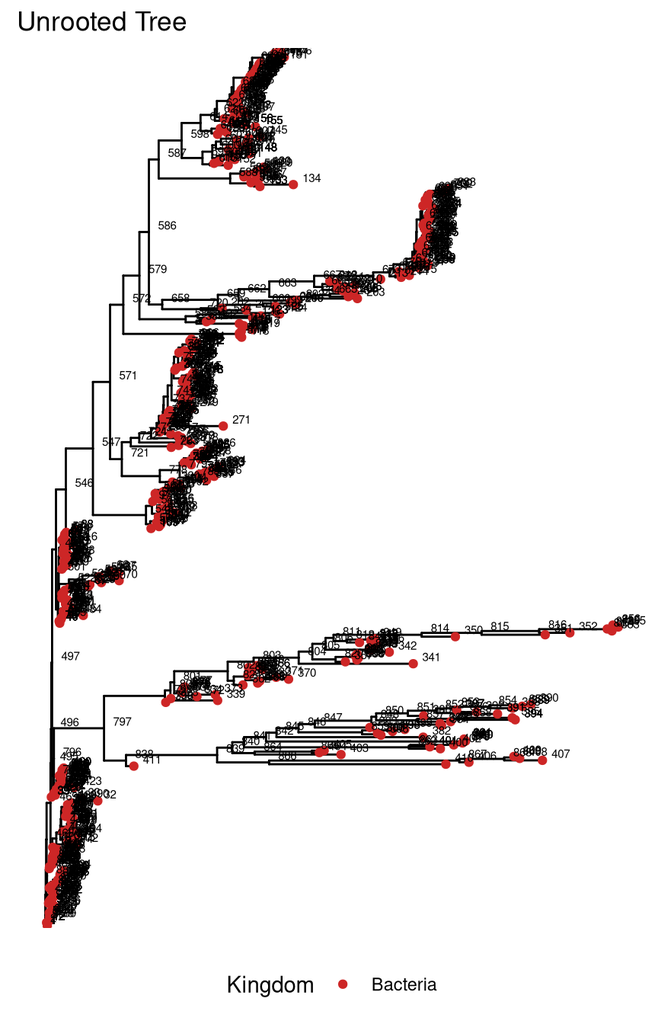

```r
kingdom_node_tree <-
  kingdom_tree +
  # Add the node label
  geom_text(aes(label=node), hjust= -0.5, vjust = -0.3, size = 2)

# Plot the tree
kingdom_node_tree
```

### Evaluate node #410

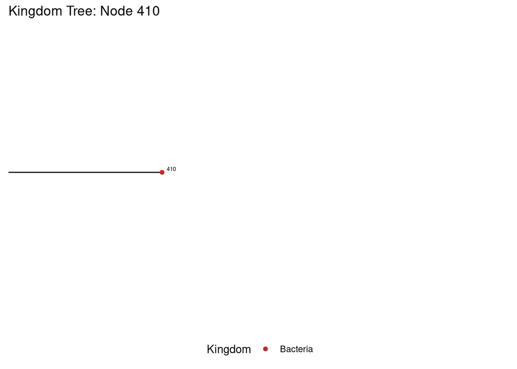

```r
# View a specific clade
# Zoom in on node that looks potentially suspicious
viewClade(kingdom_node_tree +
          labs(title = "Kingdom Tree: Node 410"),
          node = 410)
```

```r
# This plot is too zoomed in! Let's try to zoom out by looking at ancestors
# Lets see its ancestors, which will tell us each node as it steps up.
# It's ideal to look a couple nodes up but not too far!
tidytree::ancestor(unrooted_tree, 410) # The input is the TREE, not phyloseq!!
```

```
##  [1] 866 839 838 797 796 795 497 496 495 469 468 467 457 456
```

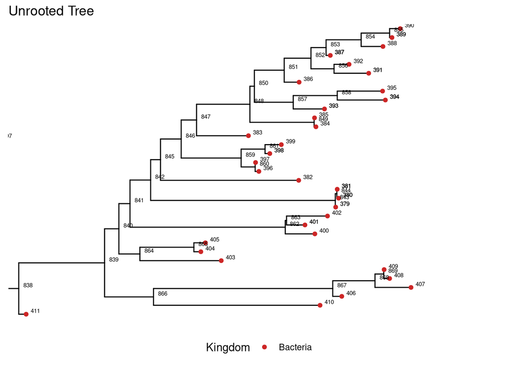

```r
# Let's evaluate 838!!
viewClade(kingdom_node_tree, 838) # even more zoomed out
```

In the subtree above, it’s clear that 410 is a long branch. Let’s inspect it some more!

```r
# Or if there are two nodes that we can see we can find its MRCA
## create tibble of tree to identify offspring
tree_tib <- as_tibble(unrooted_physeq@phy_tree)

# Inspect
head(tree_tib)
```

```
## # A tibble: 6 × 4
##   parent  node branch.length label
##    <int> <int>         <dbl> <chr>
## 1    456     1       0.00257 ASV_0073
## 2    456     2       0.00257 ASV_0341
## 3    460     3       0.00055 ASV_0519
## 4    460     4       0.00257 ASV_0521
## 5    462     5       0.00055 ASV_0425
## 6    462     6       0.00257 ASV_0490
```

```r
str(tree_tib)
```

```
## tbl_tree [908 × 4] (S3: tbl_tree/tbl_df/tbl/data.frame)
##  $ parent       : int [1:908] 456 456 460 460 462 462 465 466 466 464 ...
##  $ node         : int [1:908] 1 2 3 4 5 6 7 8 9 10 ...
##  $ branch.length: num [1:908] 0.00257 0.00257 0.00055 0.00257 0.00055 0.00257 0.00257 0.00253 0.00055 0.00054 ...
##  $ label        : chr [1:908] "ASV_0073" "ASV_0341" "ASV_0519" "ASV_0521" ...
```

```r
# lets look at the long branch
mrca_node_410 <- tidytree::MRCA(unrooted_tree, .node1 = 410, .node2 = 867) #866

# Inspect
mrca_node_410
```

```
## [1] 866
```

```r
## create dataframe to view ASVs and taxa info and to pull the ASVs
node_866 <-
  offspring(tree_tib, mrca_node_410, tiponly = TRUE) %>%
  as.data.frame() %>%
  pull(label)

# Inspect
node_866
```

```
## [1] "ASV_0337" "ASV_0465" "ASV_0259" "ASV_0290" "ASV_0347"
```

```r
# Now, let's pull out the taxonomy information, including the ASV sequence!
node_866_df <-
  unrooted_physeq %>%
  tax_table() %>%
  as.data.frame() %>%
  filter(ASV %in% node_866)

# Take a look:
glimpse(node_866_df)
```

```
## Rows: 5
## Columns: 9
## $ Kingdom <chr> "Bacteria", "Bacteria", "Bacteria", "Bacteria", "Bacteria"
## $ Phylum  <chr> "Chloroflexota", "Chloroflexota", "Chloroflexota", "Chloroflex…
## $ Class   <chr> "Chloroflexia", "Chloroflexia", "Chloroflexia", "Chloroflexia"…
## $ Order   <chr> "Thermomicrobiales", "Thermomicrobiales", "Thermomicrobiales",…
## $ Family  <chr> "JG30-KF-CM45", "JG30-KF-CM45", "JG30-KF-CM45", "JG30-KF-CM45"…
## $ Genus   <chr> NA, NA, NA, NA, "Leptolyngbya ANT.L52.2"
## $ Species <chr> NA, NA, NA, NA, NA
## $ ASV     <chr> "ASV_0337", "ASV_0465", "ASV_0259", "ASV_0290", "ASV_0347"
## $ ASVseqs <chr> "AATTTTCCGCAATGGGCGCAAGCCTGACGGAGCAACGCCGCGTGCGGGAGGACGCCTTTCG…
```

```r
# look at counts of the ASVs
unrooted_physeq %>%
  subset_taxa(., ASV %in% node_866_df$ASV) %>%
  otu_table() %>%
  data.frame() %>%
  colSums()
```

```
## SRR17327669 SRR17327670 SRR17327671 SRR17327672 SRR17327673 SRR17327674
##           0           0           0           0           0           0
## SRR17327675 SRR17327676 SRR17327677 SRR17327678 SRR17327679 SRR17327680
##           0           0           0           0           0           0
## SRR17327681 SRR17327682 SRR17327683 SRR17327684 SRR17327685 SRR17327686
##           0           0           0           0           0           0
## SRR17327687 SRR17327688 SRR17327689 SRR17327690 SRR17327691 SRR17327692
##           0           0           0           0           0           0
## SRR17327693 SRR17327694 SRR17327695 SRR17327696 SRR17327697 SRR17327698
##           0           0           0           0           0           4
## SRR17327699 SRR17327700 SRR17327701 SRR17327702 SRR17327703 SRR17327704
##           0           0           0           0           0           6
## SRR17327705 SRR17327706 SRR17327707 SRR17327708 SRR17327709 SRR17327710
##           0           0           0           0           0           0
## SRR17327711 SRR17327712 SRR17327713 SRR17327714 SRR17327715 SRR17327716
##           0           0           0           0           0           0
## SRR17327717 SRR17327718 SRR17327719 SRR17327720 SRR17327721 SRR17327722
##           0           0           0           0           0           0
## SRR17327723 SRR17327724 SRR17327725 SRR17327726 SRR17327727 SRR17327728
##           0           4           8           0           0           0
## SRR17327729 SRR17327730 SRR17327731 SRR17327732 SRR17327733 SRR17327734
##           0           0           0           0           0           0
## SRR17327735 SRR17327736 SRR17327737 SRR17327738 SRR17327739 SRR17327740
##           0           0           0           0           0           0
## SRR17327741 SRR17327742 SRR17327743 SRR17327744 SRR17327745 SRR17327746
##           0           0           0           0           0           0
## SRR17327747 SRR17327748 SRR17327749 SRR17327750 SRR17327751 SRR17327752
##           0           0           0           0           0           0
## SRR17327753 SRR17327754 SRR17327755 SRR17327756 SRR17327757 SRR17327758
##           0           0           0           0           0           0
## SRR17327759 SRR17327760 SRR17327761 SRR17327762 SRR17327763 SRR17327764
##           0           0           2           0           0           0
## SRR17327765 SRR17327766 SRR17327767 SRR17327768 SRR17327769 SRR17327770
##           0           0           0           0           0           0
## SRR17327771 SRR17327772 SRR17327773 SRR17327774 SRR17327775 SRR17327776
##           0           0           0           0           0           0
```

```r
# Lets BLAST our sequences to investigate if they are real or not
node_866_df
```

```
##           Kingdom          Phylum          Class             Order
## ASV_0337 Bacteria   Chloroflexota   Chloroflexia Thermomicrobiales
## ASV_0465 Bacteria   Chloroflexota   Chloroflexia Thermomicrobiales
## ASV_0259 Bacteria   Chloroflexota   Chloroflexia Thermomicrobiales
## ASV_0290 Bacteria   Chloroflexota   Chloroflexia Thermomicrobiales
## ASV_0347 Bacteria Cyanobacteriota Cyanobacteriia   Leptolyngbyales
##                    Family                  Genus Species      ASV
## ASV_0337     JG30-KF-CM45                   <NA>    <NA> ASV_0337
## ASV_0465     JG30-KF-CM45                   <NA>    <NA> ASV_0465
## ASV_0259     JG30-KF-CM45                   <NA>    <NA> ASV_0259
## ASV_0290     JG30-KF-CM45                   <NA>    <NA> ASV_0290
## ASV_0347 Leptolyngbyaceae Leptolyngbya ANT.L52.2    <NA> ASV_0347
##                                                                                                                                                                                                                                                                                                          …
## ASV_0337  AATTTTCCGCAATGGGCGCAAGCCTGACGGAGCAACGCCGCGTGCGGGAGGACGCCTTTC…
## ASV_0465  AATTTTCCGCAATGGGCGAAAGCCTGACGGAGCAACGCCGCGTGTGGGATGACGCTTTTC…
## ASV_0259  AATTTTCCGCAATGGGCGCAAGCCTGACGGAGCAACGCCGCGTGCGGGATGACGCGTTTC…
## ASV_0290  AATTTTCCGCAATGGGCGCAAGCCTGACGGAGCAACGCCGCGTGCGGGATGACGCTTTTC…
## ASV_0347 AATTTTCCGCAATGGGCGAAAGCCTGACGGAGCAAGACCGCGTGAGGGAGGAAGGCCTAT…
```

Interesting! We can already conclude a few things:

# BLAST

Now, copy and paste the ASV sequences into [NCBI’s Standard Nucleotide BLAST](https://blast.ncbi.nlm.nih.gov/Blast.cgi?PROGRAM=blastn&BLAST_SPEC=GeoBlast&PAGE_TYPE=BlastSearch).

## What to look for with BLAST Results?

If you’re identifying a sequence (like 16S rRNA or a gene):

- % Identity ≥ 97% for species-level 16S match (lower for genus)
- E-value ≤ 1e-5 (lower is better—e.g. 1e-20, 1e-50, etc.)
- High query coverage (ideally >90%)
- Long alignment length, especially for full genes or 16S sequences

### Most Important Values in BLAST Output

| Field | What It Means | Why It Matters | Good Values |
| --- | --- | --- | --- |
| **% Identity** | % of exact matches in aligned region | Measures sequence similarity | ≥ 97% for species (16S); lower for genus |
| **E-value** | Expected number of hits this good by chance | Lower = more statistically significant match | ≤ 1e-5 (e.g., 1e-20, 1e-50, etc.) |
| **Bit Score** | Normalized alignment score | Higher = better alignment | > 200 for strong alignments |
| **Alignment Length** | Number of bases or amino acids in the aligned region | Longer alignments are generally more reliable | As long as possible (e.g., >250 bp for 16S) |
| **Query Coverage** | % of your sequence aligned with the hit | High coverage increases confidence in identification | > 90% (ideally near 100%) |
| **Accession & Description** | ID and description of the matched sequence | Tells you what the hit is and where it comes from | Use top hit + trusted source |

#### The BLAST results:

- `ASV_0337`: “MH098275.1” One of the matches is an uncultured bacterium from a sample that was from project titled “Enhanced and complete removal of phenylurea herbicides by combinational transgenic plant-microbial remediation”. This seems legit!
  - **E-value:** 5e-170, which is a very strong alignment!
  - **% Identity:** 94%
- `ASV_0465`: “MH098297.1” One of the matches is an uncultured bacterium from a sample that was from project titled “Enhanced and complete removal of phenylurea herbicides by combinational transgenic plant-microbial remediation”. This seems legit!
  - **E-value:** 5e-180, which means there’s a 1 in 2e+179 chance (basically zero) that you would see a match this good by random chance in the database. This indicates a very strong alignment—its trustworthy! Thus, the sequences are almost certainly related (homologous) and not just similar by accident.
  - **% Identity:** 96%
- `ASV_0259`: “MH098262.1” One of the matches is an uncultured bacterium from a sample that was from project titled “Enhanced and complete removal of phenylurea herbicides by combinational transgenic plant-microbial remediation”. This seems legit!
  - **E-value:** 5e-180, which means there’s a 1 in 2e+179 chance (basically zero) that you would see a match this good by random chance in the database. This indicates a very strong alignment—its trustworthy! Thus, the sequences are almost certainly related (homologous) and not just similar by accident.
  - **% Identity:** 95.71%
- `ASV_0290`: “MH098297.1” One of the matches is an uncultured bacterium from a sample that was from project titled “Enhanced and complete removal of phenylurea herbicides by combinational transgenic plant-microbial remediation”. This seems legit!
  - **E-value:** 5e-180, which means there’s a 1 in 2e+179 chance (basically zero) that you would see a match this good by random chance in the database. This indicates a very strong alignment—its trustworthy! Thus, the sequences are almost certainly related (homologous) and not just similar by accident.
  - **% Identity:** 96.49%
- `ASV_0347`: BLAST didn’t have any matches with E-value lower than ≤ 1e-5. That’s why I consider removing this ASV (node 410)

**In conclusion…** The tree overall looks legitimate, but I think I need to remove one ASV that was in node 410.

## 4b. Prune your tree

However, if you find in your own data set that you have ASVs that need to be removed here is the code for how to do that!

```r
# Function from Joey McMurdie: https://github.com/joey711/phyloseq/issues/652
pop_taxa = function(physeq, badTaxa){
  allTaxa <-  taxa_names(physeq)
  allTaxa <- allTaxa[!(allTaxa %in% badTaxa)]
  return(prune_taxa(allTaxa, physeq))}

# I just want to remove one node. So filter that out
node_410_df <-
  unrooted_physeq %>%
  tax_table() %>%
  as.data.frame() %>%
  filter(ASV %in% node_866) %>%
  filter(ASV == "ASV_0347")

# Inspect
node_410_df
```

```
##           Kingdom          Phylum          Class           Order
## ASV_0347 Bacteria Cyanobacteriota Cyanobacteriia Leptolyngbyales
##                    Family                  Genus Species      ASV
## ASV_0347 Leptolyngbyaceae Leptolyngbya ANT.L52.2    <NA> ASV_0347
##                                                                                                                                                                                                                                                                                                          …
## ASV_0347 AATTTTCCGCAATGGGCGAAAGCCTGACGGAGCAAGACCGCGTGAGGGAGGAAGGCCTAT…
```

```r
# Let's use the pop_taxa function :)
# Recreate a phyloseq object without your unwanted ASV or node
# Lets use the example ASVs above from node_3315_df
unrooted_physeq_rm410 <-
  unrooted_physeq %>%
  pop_taxa(., node_410_df$ASV)

# Check it
unrooted_physeq_rm410
```

```
## phyloseq-class experiment-level object
## otu_table()   OTU Table:         [ 454 taxa and 108 samples ]
## sample_data() Sample Data:       [ 108 samples by 52 sample variables ]
## tax_table()   Taxonomy Table:    [ 454 taxa by 9 taxonomic ranks ]
## phy_tree()    Phylogenetic Tree: [ 454 tips and 452 internal nodes ]
```

```r
# Intuition Check: How many differ???
ntaxa(unrooted_physeq) - ntaxa(unrooted_physeq_rm410)
```

```
## [1] 1
```

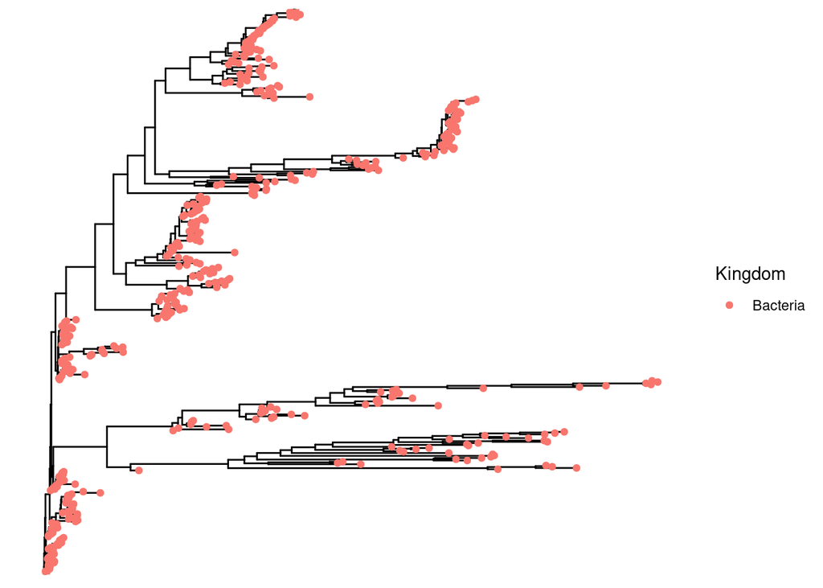

```r
# Visually inspect
ggtree(unrooted_physeq_rm410) +
  geom_tippoint(mapping = aes(color = Kingdom))
```

# 5. Root the Tree

*What does it mean to root a tree, you ask?* **Rooting a tree** means designating a specific node in a phylogenetic tree as the common ancestor of all other nodes. This establishes a direction of evolution — from the root (the oldest ancestor) to the tips (the current taxa or sequences). A tree without a root is called **unrooted**, and it only shows relationships (like how closely related things are), not the direction of descent.

## Why do we root trees in microbial community analyses?

In microbial ecology, rooted trees are especially useful for:

1. **Calculating Phylogenetic Diversity Metrics**: Metrics like Faith’s Phylogenetic Diversity and the UniFrac distances require a rooted tree to calculate how much evolutionary history is shared between communities. Without a root, the distances between taxa don’t make biological sense in terms of lineage or shared ancestry.
2. **Comparing Community Structure:** Rooting allows you to identify lineages that dominate or are lost between samples, trace evolutionary shifts in microbial composition, interpret ecological or functional patterns across a gradient (*e.g.,* salinity, pH, antibiotic exposure).
3. **Biological Interpretation** Rooted trees are required for the following interpretations, which microbial community ecologists often want to know:
   - *Are these microbes derived from a common ancestor?*
   - *Do the samples diverge from a known lineage (e.g., Proteobacteria)*?
   - *What’s the evolutionary placement of unknown organisms?*

## Methods of Rooting Trees

So, **how do we root a tree**? There are two different types of methods to root a tree:

1. **Outgroup rooting:** Choose a known lineage outside your group of interest (*e.g.,* Archaea as outgroup to Bacteria). *This is always preferred when we have a known outgroup!*
   - *Pros:*
     - Biologically meaningful — places the root based on known evolutionary relationships.
     - More accurate if your outgroup is correctly chosen and aligns well.
     - **Best for:** Hypothesis-driven studies, evolutionary interpretations, or when your dataset includes taxa from multiple domains/phyla.
   - *Cons:*
     - Requires a reliable outgroup — too distant, and it can distort the tree (long-branch attraction).
     - Not always available or appropriate (e.g., if you’re only analyzing a subset of taxa without known outgroups).
2. **Midpoint rooting:** Places the root at the midpoint of the longest path in the tree (useful when no clear outgroup exists).
   - *Pros:*
     - Simple and automatic — no need for prior biological knowledge.
     - Works well for diverse microbial datasets where outgroup info is unclear or unavailable.
     - **Best for**: Exploratory analyses, diversity metrics (like UniFrac), or when working with just bacteria/just archaea and you don’t have a good outgroup.
   - *Cons:*
     - Assumes a molecular clock — that all lineages evolve at similar rates.
     - Can misplace the root if there’s rate variation across branches.

**In Summary:**

| Rooting Method | Best When… | Pros | Cons |
| --- | --- | --- | --- |
| **Outgroup** | You have a well-placed, closely related outgroup | Biologically accurate | Needs prior knowledge; may bias tree |
| **Midpoint** | No good outgroup; exploratory or metric-focused | Fast and automatic | Assumes equal evolutionary rates |

**In summary:** If you’re working in QIIME or another microbiome pipeline and don’t have a clear outgroup, **midpoint rooting** is typically fine — especially for things like UniFrac or beta diversity. If you’re doing evolutionary or taxonomic analysis and **have a suitable outgroup, use that instead**.

## 5a. Archaeal Root

```r
# Is the tree rooted?
tidytree::is.rooted(phy_tree(unrooted_physeq))

# but first find the ASVs that are Archaea
archaeal_ASVs <-
  tax_table(unrooted_physeq) %>%
  as.data.frame() %>%
  filter(Kingdom == "Archaea") %>%
  pull(ASV)

# How many archaeal ASVs?
length(archaeal_ASVs)
archaeal_ASVs

# find the node that encompasses all Archaea
archaeal_node <-
  phytools::findMRCA(unrooted_tree,
                     tips = archaeal_ASVs, type = "node")

# Inspect
archaeal_node # node = 3394

# View clade to check it out
viewClade(kingdom_tree, archaeal_node)
viewClade(kingdom_node_tree, archaeal_node)
```

```r
# Let's highlight!
node_3394 <-
  ggtree(unrooted_physeq) +
  geom_tippoint(mapping = aes(color = Kingdom), size = 1.5) +
  #geom_text(aes(label = node), hjust = -0.7, vjust = -0.2, size = 2) +
  geom_highlight(node = archaeal_node, fill = "goldenrod1") +
  scale_color_manual(values = c("firebrick3", "cornflowerblue", "grey"))

# Visualize it
node_3394

# Root it!
archaeal_rooted_tree <-
  ape::root(phy_tree(unrooted_physeq),
            node = archaeal_node, resolve.root = TRUE)

# Check it!
tidytree::is.rooted(archaeal_rooted_tree)
```

### 6a. Merge phyloseq: Archeal Rooted Tree

```r
# Merge with physeq
archaeal_rooted_physeq <-
  merge_phyloseq(raw_preprocessed_physeq, archaeal_rooted_tree)
```

### Plot Archaeal Rooted Tree

```r
# Finally let's plot it!
# Plot rooted simple tree with no text
archaeal_rooted_tree_plot <-
  ggtree(archaeal_rooted_physeq) +
  geom_tippoint(aes(color = Kingdom)) +
  # add a title
  labs(title = "Archaeal Rooted Tree") +
  scale_color_manual(values = c("firebrick3", "cornflowerblue", "grey"))

# View it!
archaeal_rooted_tree_plot

# Plot rooted tree with text
archaeal_rooted_node_tree_plot <-
  archaeal_rooted_tree_plot +
  geom_text(aes(label = node), hjust = -0.5, vjust = -0.3, size = 1.5)

# View it!
archaeal_rooted_node_tree_plot
```

[output not shown]

INTERPRETATION #3 (If archaeal rooting): Now that you’ve rooted your tree, does the tree seem “finalized”? Are there any other branches/ASVs to inspect? Why or why not?

## 5b. Midpoint Root

*If you have Archaea or a clear outgroup, always use the outgroup rooting. If not, you can midpoint root.*

As mentioned above, if your project’s data does not have Archaea or a specified outgroup, it is possible to midpoint root the tree. Midpoint rooting calculates tip to tip distances and then places the root halfway between the two longest tips. This is why it is important to **first prune your tree of contaminating lineages!** If contaminating lineages are included in the midrooting of the tree, then it will throw off the branch lengths.

**Before midrooting the tree:**

1. Investigate and pull the ASVs in your long branches and BLAST to confirm if these are real bacterial ASVs, as mentioned above in the “long branches” section.
2. Remove any unwanted ASVs using the prune function. **Long nodes (branches) are outliers**! If we keep them in the tree, bias will be introduced into the tree reconstruction creating the **long branch attraction** error where distantly related taxa appear closely related due to a high rate of evolution on long branches.

If you **do not** have Archaea and **have** removed your long branches, then you may follow the code below to midroot your tree.

### 6b. Merge phyloseq: Midpoint Rooted Tree

```r
# Check to see if tree is rooted.. expect it to be false
is.rooted(phy_tree(unrooted_physeq))
```

```
## [1] FALSE
```

```r
# Let's midpoint root the tree
midpoint_rooted_tree <-
  unrooted_physeq %>%
  phy_tree() %>%
  phytools::midpoint.root()

# Is the new tree rooted? Should be TRUE!
is.rooted(midpoint_rooted_tree)
```

```
## [1] TRUE
```

```r
# Assign to a new phyloseq object!
# Merge tree with the raw_preprocessed physeq
midpoint_rooted_physeq <-
  merge_phyloseq(raw_preprocessed_physeq, midpoint_rooted_tree)
```

Now, we have a merged phyloseq object!

### Plot Midpoint Rooted Tree

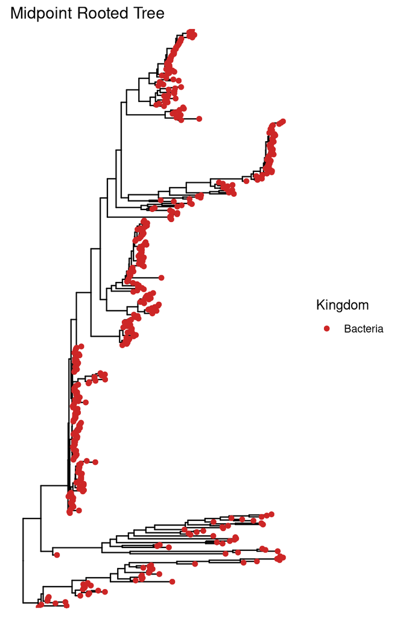

```r
# Quick inspection of tree
midpoint_rooted_tree_plot <-
  ggtree(midpoint_rooted_physeq) +
  geom_tippoint(mapping = aes(color = Kingdom)) +
  geom_tippoint(aes(color = Kingdom)) +
  labs(title = "Midpoint Rooted Tree") +
  scale_color_manual(values = c("firebrick3", "cornflowerblue", "grey"))

# Look at the tree
midpoint_rooted_tree_plot
```

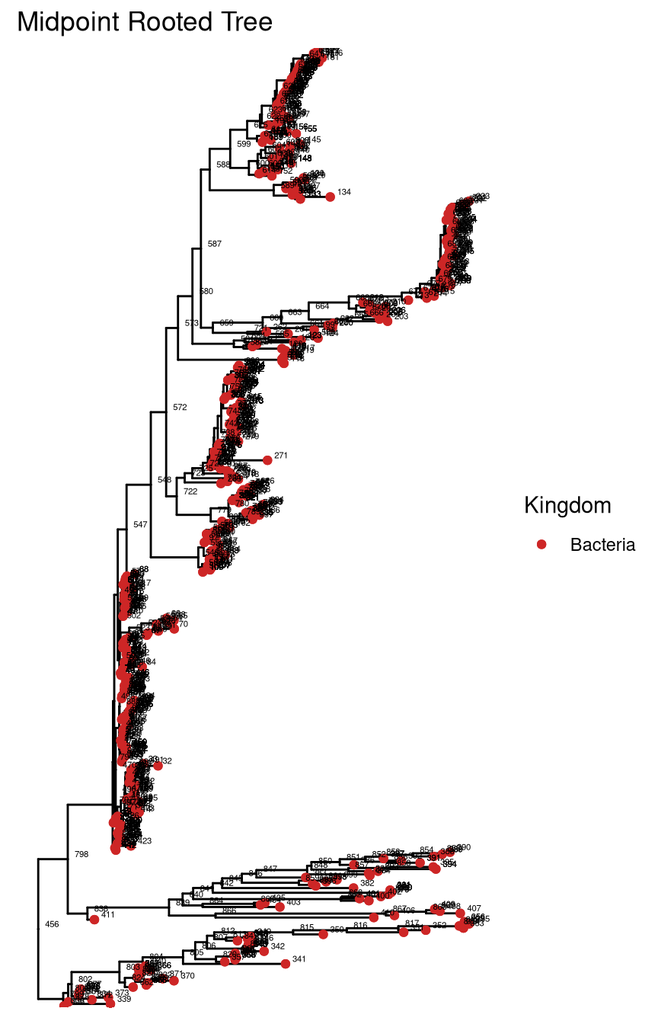

```r
# Add nodes
midpoint_rooted_tree_node_plot <-
  midpoint_rooted_tree_plot +
  geom_text(aes(label = node), hjust = -0.5, vjust = -0.3, size = 1.5)

# View it
midpoint_rooted_tree_node_plot
```

## 7. Save phyloseq objects

The phyloseq objects can be saved in one file as a list of objects. Or, we can save them individually. Two examples are below:

### Save multiple phyloseq objects as a list

```r
# Take a quick look at the two!
#archaeal_rooted_physeq # Archaeal rooted tree
midpoint_rooted_physeq # Midpiont rooted tree
```

```
## phyloseq-class experiment-level object
## otu_table()   OTU Table:         [ 455 taxa and 108 samples ]
## sample_data() Sample Data:       [ 108 samples by 52 sample variables ]
## tax_table()   Taxonomy Table:    [ 455 taxa by 9 taxonomic ranks ]
## phy_tree()    Phylogenetic Tree: [ 455 tips and 454 internal nodes ]
```

```r
# Save both phyloseq objects to one .RData file
save("midpoint_rooted_physeq",
     file = "data/04_PhylogeneticTree/phytree_preprocessed_physeqs.RData")
```

### Save individual phyloseq objects

```r
# Now, save archaeal rooted phyloseq object
#save(archaeal_rooted_physeq,
 #    file = "data/04_PhylogeneticTree/archaeal_rooted_physeq.RData")

# Now, save midpoint rooted phyloseq object
save(midpoint_rooted_physeq,
     file = "data/04_PhylogeneticTree/midpoint_rooted_physeq.RData")
```

Now that we have our rooted trees inside of a phyloseq object, we can go forth and begin our next analysis!

# Final info for Reproducibility

## Check Render Time

```r
# Take the time now that we are at the end of the script
end_time <- Sys.time()
end_time
```

```
## [1] "2025-03-31 01:44:17 EDT"
```

```r
# Echo the elapsed time
elapsed_time <- round((end_time - start_time), 3)
elapsed_time
```

```
## Time difference of 23.167 secs
```